# R Notebook

This is my attempt to identify a leaing cause of fatigue in players of the Canadian Women’s Rugby Sevens team during the 2017-2018 Rugby World Series. The data was provided by the Canadian national team and some aspects of the code were borrowed from internet tutorials that are cited below.

Below is the intial import and cleaning of the data.

```r
library(dplyr)
library(lubridate)
library(tidyr)
library(ggplot2)
library(xlsx)
library(ISLR)
library(leaps)
library(tidyverse)
library(cowplot)
library(corrplot)
library(tree)
library(rattle)
library(rpart.plot)
library(caret)
library(e1071)

setwd("C:/Users/Owner/Desktop/UCLA INTENSIVE/Capstone2/data")

games = read.csv("games.csv")
commonwealth = read.csv("CommonWealth.csv")
monitored_per_game = read.csv("MonitoredPerGame.csv")
rpe = read.csv("rpe.csv")
wellness = read.csv("wellness.csv")
who_played_what = read.csv("whoPlayedWhat.csv")

colnames(games)[colnames(games) == "ï..GameID"] <- "GameID"
who_played_what = who_played_what[,2:19]
games = left_join(games, who_played_what)
colnames(monitored_per_game)[colnames(monitored_per_game) == "ï..GameID"] <- "GameID"
monitored_per_game = monitored_per_game[,1:2]

games$Date = mdy(games$Date)
wellness$Date = ymd(wellness$Date)
rpe$Date = ymd(rpe$Date)

wellness$BedTime <- as.character(wellness$BedTime) %>%
  hms::as.hms(wellness$BedTime)
wellness$WakeTime <- as.character(wellness$WakeTime) %>%
  hms::as.hms(wellness$WakeTime)

for(i in 11:27) {
  games[,i] = as.factor(games[,i])
}

str(games)
```

```
'data.frame':   38 obs. of  27 variables:
 $ GameID           : int  1 2 3 4 5 6 7 8 9 10 ...
 $ Date             : Date, format: "2017-11-30" "2017-11-30" "2017-11-30" "2017-12-01" ...
 $ Tournament       : Factor w/ 7 levels "Commonwealth",..: 2 2 2 2 2 2 6 6 6 6 ...
 $ TournamentGame   : int  1 2 3 4 5 6 1 2 3 4 ...
 $ Team             : Factor w/ 1 level "Canada": 1 1 1 1 1 1 1 1 1 1 ...
 $ Opponent         : Factor w/ 13 levels "Australia","Brazil",..: 12 6 4 5 1 10 4 6 10 5 ...
 $ Outcome          : Factor w/ 2 levels "L","W": 2 2 2 2 1 1 2 2 2 2 ...
 $ TeamPoints       : int  19 31 31 24 7 5 24 24 19 28 ...
 $ TeamPointsAllowed: int  0 0 14 19 25 10 12 12 5 12 ...
 $ MonitoredAvg     : num  21.8 21.8 21.8 17.6 17.4 ...
 $ Player1          : Factor w/ 2 levels "FALSE","TRUE": 1 1 1 1 1 1 1 1 1 1 ...
 $ Player2          : Factor w/ 1 level "TRUE": 1 1 1 1 1 1 1 1 1 1 ...
 $ Player3          : Factor w/ 2 levels "FALSE","TRUE": 2 2 2 2 2 2 2 2 2 2 ...
 $ Player4          : Factor w/ 2 levels "FALSE","TRUE": 2 2 2 2 2 2 2 2 2 2 ...
 $ Player5          : Factor w/ 2 levels "FALSE","TRUE": 1 1 1 1 1 1 1 1 1 1 ...
 $ Player6          : Factor w/ 2 levels "FALSE","TRUE": 2 2 2 2 2 1 1 1 1 1 ...
 $ Player7          : Factor w/ 2 levels "FALSE","TRUE": 2 2 2 2 2 2 2 2 2 2 ...
 $ Player8          : Factor w/ 2 levels "FALSE","TRUE": 2 2 2 2 2 2 2 2 2 2 ...
 $ Player9          : Factor w/ 2 levels "FALSE","TRUE": 2 2 2 2 2 2 2 2 2 2 ...
 $ Player10         : Factor w/ 2 levels "FALSE","TRUE": 2 2 2 2 2 2 2 2 2 2 ...
 $ Player11         : Factor w/ 1 level "TRUE": 1 1 1 1 1 1 1 1 1 1 ...
 $ Player12         : Factor w/ 2 levels "FALSE","TRUE": 2 2 2 2 2 2 2 2 2 2 ...
 $ Player13         : Factor w/ 1 level "TRUE": 1 1 1 1 1 1 1 1 1 1 ...
 $ Player14         : Factor w/ 2 levels "FALSE","TRUE": 1 1 1 2 1 2 2 2 2 2 ...
 $ Player15         : Factor w/ 2 levels "FALSE","TRUE": 1 1 1 2 1 1 1 1 1 1 ...
 $ Player16         : Factor w/ 2 levels "FALSE","TRUE": 1 1 1 2 1 1 1 1 1 1 ...
 $ Player17         : Factor w/ 2 levels "FALSE","TRUE": 2 2 2 2 2 2 1 1 1 1 ...
```

```r
str(wellness)
```

```
'data.frame':   5011 obs. of  19 variables:
 $ Date               : Date, format: "2018-07-21" "2018-07-21" "2018-07-21" "2018-07-21" ...
 $ PlayerID           : int  1 2 3 4 5 7 10 11 13 14 ...
 $ Fatigue            : int  3 4 3 2 5 2 2 4 4 3 ...
 $ Soreness           : int  3 3 3 3 3 2 2 3 3 3 ...
 $ Desire             : int  2 4 5 5 4 5 4 6 5 4 ...
 $ Irritability       : int  3 4 4 4 4 4 4 4 4 4 ...
 $ BedTime            : 'hms' num  23:00:00 23:00:00 22:30:00 00:30:00 ...
  ..- attr(*, "units")= chr "secs"
 $ WakeTime           : 'hms' num  07:00:00 07:00:00 06:30:00 07:00:00 ...
  ..- attr(*, "units")= chr "secs"
 $ SleepHours         : num  8 8 8 6.5 7.25 9 7.25 8 8 8.75 ...
 $ SleepQuality       : int  2 4 4 1 4 3 3 3 4 4 ...
 $ MonitoringScore    : int  13 19 19 15 20 16 15 20 20 18 ...
 $ Pain               : Factor w/ 2 levels "No","Yes": 1 2 1 1 1 1 1 1 1 1 ...
 $ Illness            : Factor w/ 3 levels "No","Slightly Off",..: 1 1 1 1 1 1 2 2 1 1 ...
 $ Menstruation       : Factor w/ 2 levels "No","Yes": 2 2 1 2 1 1 1 1 1 1 ...
 $ Nutrition          : Factor w/ 3 levels "Excellent","Okay",..: 1 NA NA 1 2 1 1 1 1 1 ...
 $ NutritionAdjustment: Factor w/ 3 levels "I Don't Know",..: 3 NA NA 3 3 3 3 3 3 3 ...
 $ USGMeasurement     : Factor w/ 2 levels "No","Yes": 1 2 2 2 2 2 2 2 2 2 ...
 $ USG                : num  NA 1.01 1.02 1.02 1.02 ...
 $ TrainingReadiness  : Factor w/ 21 levels "0%","10%","100%",..: 1 1 3 21 3 21 16 3 3 3 ...
```

```r
str(rpe)
```

```
'data.frame':   8860 obs. of  14 variables:
 $ Date             : Date, format: "2018-07-21" "2018-07-21" "2018-07-21" "2018-07-20" ...
 $ PlayerID         : int  13 13 13 11 11 11 13 13 13 1 ...
 $ Training         : Factor w/ 2 levels "No","Yes": 2 2 2 2 2 2 2 2 2 2 ...
 $ SessionType      : Factor w/ 7 levels "Combat","Conditioning",..: 4 3 3 3 3 4 3 3 4 5 ...
 $ Duration         : int  5 29 27 36 36 15 27 24 10 60 ...
 $ RPE              : int  0 7 9 6 8 2 6 6 0 3 ...
 $ SessionLoad      : int  0 203 243 216 288 30 162 144 0 180 ...
 $ DailyLoad        : int  446 NA NA 534 NA NA 306 NA NA 180 ...
 $ AcuteLoad        : num  323 NA NA 256 NA ...
 $ ChronicLoad      : num  303 NA NA 344 NA ...
 $ AcuteChronicRatio: num  1.07 NA NA 0.74 NA NA 0.9 NA NA 0.63 ...
 $ ObjectiveRating  : int  NA NA NA 9 9 9 NA NA NA NA ...
 $ FocusRating      : int  NA NA NA 10 10 10 NA NA NA NA ...
 $ BestOutOfMyself  : Factor w/ 3 levels "Absolutely","Not at all",..: 2 2 2 1 1 1 2 2 2 NA ...
```

```r
summary(games)
```

```
     GameID           Date                   Tournament TournamentGame      Team         Opponent  Outcome   TeamPoints
 Min.   : 1.00   Min.   :2017-11-30   Commonwealth:5    Min.   :1.000   Canada:38   Russia   : 6   L:15    Min.   : 0.00
 1st Qu.:10.25   1st Qu.:2018-01-27   Dubai       :6    1st Qu.:2.000               Ireland  : 5   W:23    1st Qu.:14.75
 Median :19.50   Median :2018-04-21   Kitakyushu  :5    Median :3.000               Australia: 4           Median :21.50
 Mean   :19.50   Mean   :2018-04-05   Langford    :6    Mean   :3.263               Fiji     : 4           Mean   :21.21
 3rd Qu.:28.75   3rd Qu.:2018-06-01   Paris       :6    3rd Qu.:4.750               France   : 4           3rd Qu.:28.75
 Max.   :38.00   Max.   :2018-07-21   Sydney      :6    Max.   :6.000               England  : 3           Max.   :43.00
                                      World Cup   :4                                (Other)  :12
 TeamPointsAllowed  MonitoredAvg    Player1   Player2    Player3    Player4    Player5    Player6    Player7    Player8
 Min.   : 0.00     Min.   :15.36   FALSE:10   TRUE:38   FALSE:12   FALSE: 1   FALSE:10   FALSE:33   FALSE: 4   FALSE: 4
 1st Qu.:12.00     1st Qu.:17.61   TRUE :28             TRUE :26   TRUE :37   TRUE :28   TRUE : 5   TRUE :34   TRUE :34
 Median :14.00     Median :19.42
 Mean   :16.53     Mean   :19.36
 3rd Qu.:24.00     3rd Qu.:21.60
 Max.   :34.00     Max.   :22.20

  Player9    Player10  Player11   Player12  Player13   Player14   Player15   Player16   Player17
 FALSE:28   FALSE:12   TRUE:38   FALSE:10   TRUE:38   FALSE:20   FALSE:17   FALSE:10   FALSE:32
 TRUE :10   TRUE :26             TRUE :28             TRUE :18   TRUE :21   TRUE :28   TRUE : 6
```

```r
summary(wellness)
```

```
      Date               PlayerID         Fatigue         Soreness         Desire      Irritability     BedTime
 Min.   :2017-08-01   Min.   : 1.000   Min.   :1.000   Min.   :1.000   Min.   :1.00   Min.   :1.000   Length:5011
 1st Qu.:2017-10-24   1st Qu.: 4.000   1st Qu.:3.000   1st Qu.:3.000   1st Qu.:3.00   1st Qu.:4.000   Class1:hms
 Median :2018-01-15   Median : 9.000   Median :3.000   Median :3.000   Median :4.00   Median :4.000   Class2:difftime
 Mean   :2018-01-18   Mean   : 8.712   Mean   :3.412   Mean   :3.352   Mean   :3.83   Mean   :3.969   Mode  :numeric
 3rd Qu.:2018-04-14   3rd Qu.:13.000   3rd Qu.:4.000   3rd Qu.:4.000   3rd Qu.:4.00   3rd Qu.:4.000
 Max.   :2018-07-21   Max.   :17.000   Max.   :7.000   Max.   :7.000   Max.   :7.00   Max.   :7.000

   WakeTime          SleepHours      SleepQuality   MonitoringScore  Pain              Illness     Menstruation     Nutrition
 Length:5011       Min.   : 0.750   Min.   :1.000   Min.   : 5.00   No :4423   No          :4456   No  :4285    Excellent:2713
 Class1:hms        1st Qu.: 8.000   1st Qu.:3.000   1st Qu.:16.00   Yes: 588   Slightly Off: 421   Yes : 710    Okay     :1398
 Class2:difftime   Median : 8.750   Median :4.000   Median :18.00              Yes         : 134   NA's:  16    Poor     :  63
 Mode  :numeric    Mean   : 8.662   Mean   :3.805   Mean   :18.37                                               NA's     : 837
                   3rd Qu.: 9.250   3rd Qu.:4.000   3rd Qu.:20.00
                   Max.   :22.500   Max.   :7.000   Max.   :35.00

   NutritionAdjustment USGMeasurement      USG        TrainingReadiness
 I Don't Know: 100     No  :4208      Min.   :1.003   100%   :1440
 No          : 439     Yes : 635      1st Qu.:1.014   0%     :1007
 Yes         :3727     NA's: 168      Median :1.017   90%    : 641
 NA's        : 745                    Mean   :1.022   95%    : 591
                                      3rd Qu.:1.020   85%    : 296
                                      Max.   :1.200   80%    : 226
                                      NA's   :4382    (Other): 810
```

```r
summary(rpe)
```

```
      Date               PlayerID      Training              SessionType      Duration           RPE         SessionLoad
 Min.   :2017-08-01   Min.   : 1.000   No :1238   Strength         :1909   Min.   :  2.00   Min.   :0.000   Min.   :   0.0
 1st Qu.:2017-10-24   1st Qu.: 5.000   Yes:7622   Skills           :1859   1st Qu.: 33.00   1st Qu.:3.000   1st Qu.: 120.0
 Median :2018-01-10   Median : 9.000              Speed            :1245   Median : 60.00   Median :4.000   Median : 216.0
 Mean   :2018-01-16   Mean   : 9.019              Mobility/Recovery: 992   Mean   : 55.66   Mean   :4.167   Mean   : 252.7
 3rd Qu.:2018-04-09   3rd Qu.:13.000              Conditioning     : 960   3rd Qu.: 75.00   3rd Qu.:5.000   3rd Qu.: 360.0
 Max.   :2018-07-21   Max.   :17.000              (Other)          : 656   Max.   :245.00   Max.   :9.000   Max.   :1440.0
                                                  NA's             :1239   NA's   :1239     NA's   :1239    NA's   :1239
   DailyLoad        AcuteLoad      ChronicLoad     AcuteChronicRatio ObjectiveRating   FocusRating       BestOutOfMyself
 Min.   :   0.0   Min.   :  3.1   Min.   :  1.43   Min.   :0.010     Min.   : 0.000   Min.   : 0.000   Absolutely:2438
 1st Qu.: 290.0   1st Qu.:188.6   1st Qu.:251.01   1st Qu.:0.640     1st Qu.: 7.000   1st Qu.: 8.000   Not at all: 368
 Median : 580.0   Median :299.3   Median :334.29   Median :0.920     Median : 8.000   Median : 8.000   Somewhat  : 213
 Mean   : 612.6   Mean   :316.3   Mean   :335.38   Mean   :1.051     Mean   : 7.918   Mean   : 8.123   NA's      :5841
 3rd Qu.: 900.0   3rd Qu.:432.1   3rd Qu.:424.84   3rd Qu.:1.270     3rd Qu.: 9.000   3rd Qu.: 9.000
 Max.   :2300.0   Max.   :790.7   Max.   :695.89   Max.   :4.020     Max.   :10.000   Max.   :10.000
 NA's   :5711     NA's   :4511    NA's   :4477     NA's   :4511      NA's   :4136     NA's   :4109
```

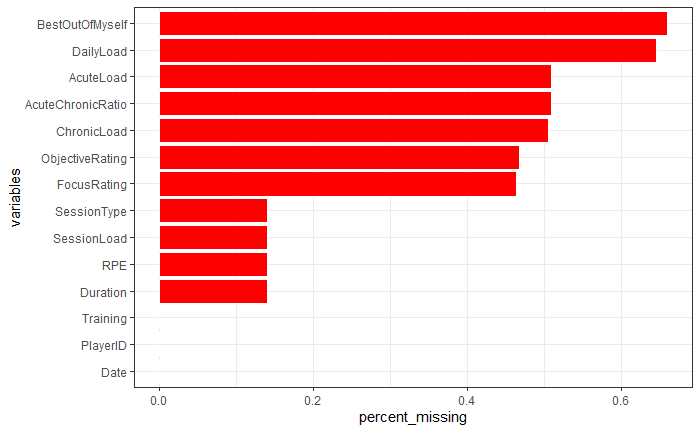

```r
##Visualize missing data
missing_data <- rpe %>% summarise_all(funs(sum(is.na(.))/n()))
missing_data <- gather(missing_data, key = "variables", value = "percent_missing")
ggplot(missing_data, aes(x = reorder(variables, percent_missing), y = percent_missing)) +
  geom_bar(stat = "identity", fill = "red", aes(color = I('white')), size = 0.3)+
  xlab('variables')+
  coord_flip()+
  theme_bw()
```

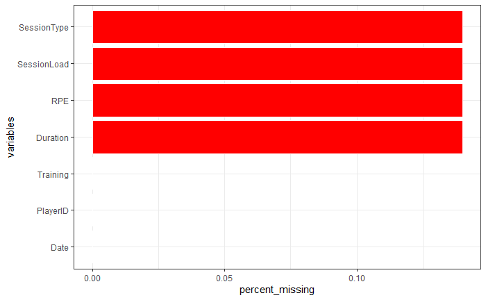

```r
rpe1 = rpe[,c("Date","PlayerID","Training","SessionType","Duration","RPE","SessionLoad")]
acr = rpe[,c("Date","PlayerID","AcuteLoad","ChronicLoad","AcuteChronicRatio")]
acr = acr[complete.cases(acr),]

missing_data <- rpe1 %>% summarise_all(funs(sum(is.na(.))/n()))
missing_data <- gather(missing_data, key = "variables", value = "percent_missing")
ggplot(missing_data, aes(x = reorder(variables, percent_missing), y = percent_missing)) +
  geom_bar(stat = "identity", fill = "red", aes(color = I('white')), size = 0.3)+
  xlab('variables')+
  coord_flip()+
  theme_bw()
```

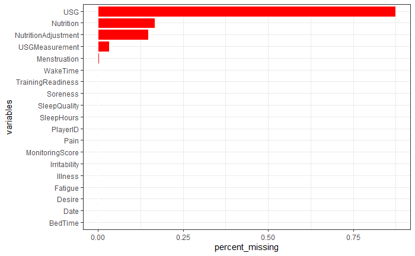

```r
missing_data <- wellness %>% summarise_all(funs(sum(is.na(.))/n()))
missing_data <- gather(missing_data, key = "variables", value = "percent_missing")
ggplot(missing_data, aes(x = reorder(variables, percent_missing), y = percent_missing)) +
  geom_bar(stat = "identity", fill = "red", aes(color = I('white')), size = 0.3)+
  xlab('variables')+
  coord_flip()+
  theme_bw()
```

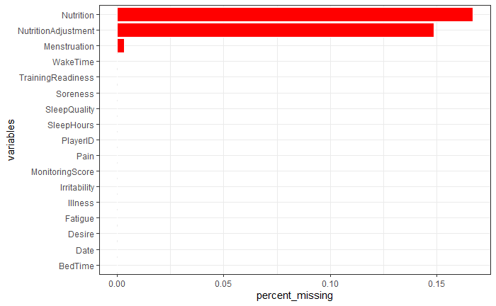

```r
wellness1 = wellness[-c(17:18)]
wellness1$TrainingReadiness <- as.character(wellness1$TrainingReadiness)
wellness1$TrainingReadiness <- sub('\\%',"",wellness1$TrainingReadiness)
wellness1$TrainingReadiness <- as.numeric(wellness1$TrainingReadiness)

missing_data <- wellness1 %>% summarise_all(funs(sum(is.na(.))/n()))
missing_data <- gather(missing_data, key = "variables", value = "percent_missing")
ggplot(missing_data, aes(x = reorder(variables, percent_missing), y = percent_missing)) +
  geom_bar(stat = "identity", fill = "red", aes(color = I('white')), size = 0.3)+
  xlab('variables')+
  coord_flip()+
  theme_bw()
```

```r
##clean up rpe
rpe2 = rpe1

#from https://stackoverflow.com/questions/45298997/merge-two-rows-in-data-frame
#df %>%
#group_by(Date, Origin) %>%
#  summarise_all(funs(trimws(paste(., collapse = ''))))

#get a sum of duration, mean(RPE), and sum SessionLoad
rpe2 = rpe2 %>%
  group_by(Date, PlayerID) %>%
  summarise(Training = paste(Training, collapse=','), SessionType = paste(SessionType, collapse=', '),
    Duration = sum(Duration),RPE = mean(RPE),SessionLoad=sum(SessionLoad))
rpe2$SessionType = as.factor(rpe2$SessionType)
str(rpe2)
```

```
Classes ‘grouped_df’, ‘tbl_df’, ‘tbl’ and 'data.frame': 4331 obs. of  7 variables:
 $ Date       : Date, format: "2017-08-01" "2017-08-01" "2017-08-01" "2017-08-01" ...
 $ PlayerID   : int  1 3 5 8 9 10 11 12 13 15 ...
 $ Training   : chr  "Yes,Yes" "Yes,Yes" "Yes,Yes" "Yes,Yes" ...
 $ SessionType: Factor w/ 216 levels "Conditioning",..: 180 180 180 180 1 180 180 180 180 180 ...
 $ Duration   : int  150 135 90 135 45 140 125 140 150 90 ...
 $ RPE        : num  3.5 5 3.5 2.5 9 4.5 4 2 5.5 3 ...
 $ SessionLoad: int  540 675 330 345 405 640 500 280 840 300 ...
 - attr(*, "groups")=Classes ‘tbl_df’, ‘tbl’ and 'data.frame':  355 obs. of  2 variables:
  ..$ Date : Date, format: "2017-08-01" "2017-08-02" "2017-08-03" "2017-08-04" ...
  ..$ .rows:List of 355
  .. ..$ : int  1 2 3 4 5 6 7 8 9 10
  .. ..$ : int  11 12 13 14 15 16 17 18 19 20 ...
  .. ..$ : int  23 24 25 26 27 28 29 30 31 32
  .. ..$ : int  33 34 35 36 37 38 39 40 41
  .. ..$ : int  42 43 44 45 46 47 48
  .. ..$ : int  49 50 51 52 53 54 55
  .. ..$ : int  56 57 58 59 60 61 62 63 64 65 ...
  .. ..$ : int  70 71 72 73 74 75 76 77 78 79 ...
  .. ..$ : int  83 84 85 86 87 88 89 90 91 92 ...
  .. ..$ : int  95 96 97 98 99 100 101 102 103 104 ...
  .. ..$ : int  109 110 111 112 113 114 115 116 117 118 ...
  .. ..$ : int  120 121 122 123 124 125 126 127 128
  .. ..$ : int  129 130 131 132 133 134 135 136 137 138 ...
  .. ..$ : int  141 142 143 144 145 146 147 148 149 150 ...
  .. ..$ : int  156 157 158 159 160 161 162 163 164 165 ...
  .. ..$ : int  169 170 171 172 173 174 175 176 177 178 ...
  .. ..$ : int  185 186 187 188 189 190 191 192 193 194 ...
  .. ..$ : int  199 200 201 202 203 204 205 206 207 208 ...
  .. ..$ : int  215 216 217 218 219 220 221 222 223 224 ...
  .. ..$ : int  228 229 230 231 232 233 234 235 236 237 ...
  .. ..$ : int  239 240 241 242 243 244 245 246 247 248 ...
  .. ..$ : int  255 256 257 258 259 260 261 262 263 264 ...
  .. ..$ : int  270 271 272 273 274 275 276 277 278 279 ...
  .. ..$ : int  286 287 288 289 290 291 292 293 294 295 ...
  .. ..$ : int  300 301 302 303 304 305 306 307 308 309 ...
  .. ..$ : int  314 315 316 317 318 319 320 321 322 323 ...
  .. ..$ : int  326 327 328 329 330 331 332 333 334 335 ...
  .. ..$ : int  339 340 341 342 343 344 345 346 347 348 ...
  .. ..$ : int  353 354 355 356 357 358 359 360 361 362 ...
```

[output cut: 57 more lines]

```
  .. ..$ : int  1129 1130 1131 1132 1133 1134 1135 1136 1137 1138 ...
  .. ..$ : int  1141 1142 1143 1144 1145 1146 1147 1148 1149 1150 ...
  .. ..$ : int  1156 1157 1158 1159 1160 1161 1162 1163 1164 1165 ...
  .. ..$ : int  1172 1173 1174 1175 1176 1177 1178 1179 1180 1181 ...
  .. ..$ : int  1187 1188 1189 1190 1191 1192 1193 1194 1195 1196 ...
  .. ..$ : int  1199 1200 1201 1202 1203 1204 1205 1206 1207 1208 ...
  .. ..$ : int  1211 1212 1213 1214 1215 1216 1217 1218 1219 1220 ...
  .. ..$ : int  1225 1226 1227 1228 1229 1230 1231 1232 1233 1234 ...
  .. ..$ : int  1241 1242 1243 1244 1245 1246 1247 1248 1249 1250 ...
  .. ..$ : int  1253 1254 1255 1256 1257 1258 1259 1260 1261 1262 ...
  .. ..$ : int  1267 1268 1269 1270 1271 1272 1273 1274 1275 1276 ...
  .. ..$ : int  1279 1280 1281 1282 1283 1284 1285 1286 1287 1288 ...
  .. ..$ : int  1294 1295 1296 1297 1298 1299 1300 1301 1302 1303 ...
  .. .. [list output truncated]
  ..- attr(*, ".drop")= logi TRUE
```

```r
##EDA
wellness1$PlayerID = as.factor(wellness1$PlayerID)
rpe2$PlayerID = as.factor(rpe2$PlayerID)
```

As one can see, I chose to eliminate a majority of the RPE variables as they had large percentages of their data missing. Though it’s somewhat unideal as the eliminated variables are some of the most objective pieces of data within the set, I found it cleaner and more workable to move on without them.

In the following chunk of code, I performed some EDA.

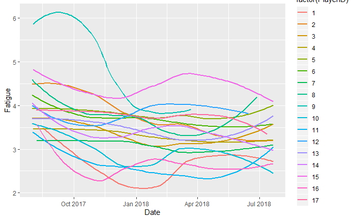

```r
ggplot(wellness1, aes(x=Date, y=Fatigue, color=factor(PlayerID),label = factor(PlayerID))) +
  geom_smooth(se=F)
```

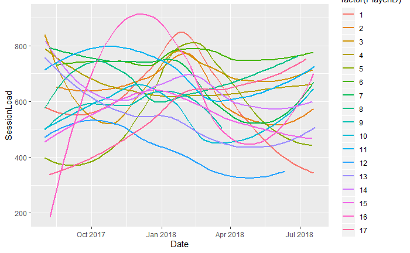

```r
ggplot(rpe2, aes(x=Date, y=SessionLoad, color=factor(PlayerID))) +
  geom_smooth(se=F)
```

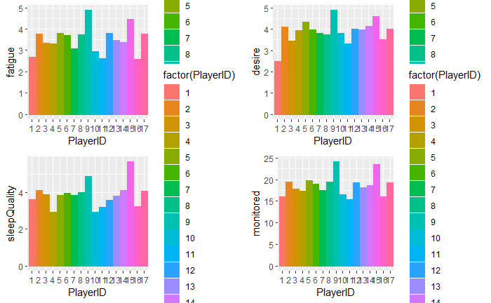

```r
avgPlayer = wellness1
avgPlayer = wellness1 %>%
  group_by(PlayerID) %>%
  summarise(avgPlayer$fatigue <- mean(Fatigue),avgPlayer$soreness <- mean(Soreness), avgPlayer$desire <- mean(Desire),
            avgPlayer$irritability <- mean(Irritability), avgPlayer$sleepHours <- mean(SleepHours),
            avgPlayer$sleepQuality <- mean(SleepQuality), avgPlayer$monitored <- mean(MonitoringScore))
colnames(avgPlayer) <- c("PlayerID","fatigue","soreness","desire","irritability","sleepHours","sleepQuality","monitored")
avgPlayer$PlayerID <- as.factor(avgPlayer$PlayerID)

plot_grid(
  ggplot(avgPlayer, aes(PlayerID,fatigue,label=factor(PlayerID),color=factor(PlayerID),fill=factor(PlayerID)))+
    geom_bar(stat="identity"),
  ggplot(avgPlayer, aes(PlayerID,desire,label=factor(PlayerID),color=factor(PlayerID),fill=factor(PlayerID)))+
    geom_bar(stat="identity"),
  ggplot(avgPlayer, aes(PlayerID,sleepQuality,label=factor(PlayerID),color=factor(PlayerID),fill=factor(PlayerID)))+
    geom_bar(stat="identity"),
  ggplot(avgPlayer, aes(PlayerID,monitored,label=factor(PlayerID),color=factor(PlayerID),fill=factor(PlayerID)))+
    geom_bar(stat="identity")
)
```

The first graph illustrates the reported fatigue levels of the players over the course of the season, and shows distinctly some players who often reported either higher or lower fatigue ratings than their fellow players. The following chart illustrates the reported SessionLoad across the season, a.k.a. a quanitfied variable that describes the intensity of their training/gameplay. The final charts track each player’s respective reported fatigue, desire, sleepQuality, and monitoredAVG (a collected average of each player’s self-reported scores) averaged over the course of the season. One can see that the shapes of each self-reported variable are fairly similar compared to fatigue, suggesting a relationship between reported fatigue and other self-reported factors.

Below are some initial linear models.

```r
well.lm1 = lm(Fatigue~.-MonitoringScore,data=wellness1)
summary(well.lm1)
```

```
Call:
lm(formula = Fatigue ~ . - MonitoringScore, data = wellness1)

Residuals:
     Min       1Q   Median       3Q      Max
-3.14391 -0.38231  0.03154  0.40068  3.09605

Coefficients:
                         Estimate Std. Error t value Pr(>|t|)
(Intercept)             8.409e+00  1.784e+00   4.714 2.51e-06 ***
Date                   -5.239e-04  1.010e-04  -5.189 2.22e-07 ***
PlayerID2               9.346e-01  9.656e-02   9.679  < 2e-16 ***
PlayerID3               4.359e-01  5.876e-02   7.420 1.42e-13 ***
PlayerID4               3.476e-01  6.051e-02   5.745 9.87e-09 ***
PlayerID5               5.868e-01  7.060e-02   8.311  < 2e-16 ***
PlayerID6               6.145e-01  6.444e-02   9.536  < 2e-16 ***
PlayerID7               7.708e-02  5.942e-02   1.297 0.194646
PlayerID8               6.745e-01  7.687e-02   8.775  < 2e-16 ***
PlayerID9               9.173e-01  6.852e-02  13.389  < 2e-16 ***
PlayerID10              2.000e-01  6.809e-02   2.937 0.003331 **
PlayerID11              5.429e-02  5.964e-02   0.910 0.362688
PlayerID12              7.140e-01  7.494e-02   9.527  < 2e-16 ***
PlayerID13              4.369e-01  6.043e-02   7.229 5.77e-13 ***
PlayerID14              1.905e-01  6.537e-02   2.914 0.003591 **
PlayerID15              5.196e-01  6.958e-02   7.468 9.90e-14 ***
PlayerID16             -1.267e-01  5.822e-02  -2.176 0.029628 *
PlayerID17              6.328e-01  7.501e-02   8.437  < 2e-16 ***
Soreness                2.467e-01  1.184e-02  20.841  < 2e-16 ***
Desire                  2.691e-01  1.413e-02  19.043  < 2e-16 ***
Irritability            8.877e-02  1.607e-02   5.523 3.55e-08 ***
BedTime                 1.670e-06  4.790e-07   3.486 0.000496 ***
WakeTime                6.841e-06  2.559e-06   2.673 0.007546 **
SleepHours              4.576e-02  8.940e-03   5.119 3.22e-07 ***
SleepQuality            1.988e-01  1.105e-02  17.990  < 2e-16 ***
PainYes                 9.875e-02  4.034e-02   2.448 0.014402 *
IllnessSlightly Off    -1.861e-02  3.812e-02  -0.488 0.625418
IllnessYes             -3.281e-01  6.589e-02  -4.979 6.64e-07 ***
MenstruationYes         7.155e-03  2.778e-02   0.258 0.796738
NutritionOkay          -1.011e-01  2.974e-02  -3.400 0.000681 ***
NutritionPoor          -2.270e-01  9.245e-02  -2.456 0.014107 *
NutritionAdjustmentNo   1.985e-01  7.508e-02   2.644 0.008233 **
NutritionAdjustmentYes  2.120e-01  6.906e-02   3.070 0.002154 **
TrainingReadiness      -1.546e-04  3.803e-04  -0.406 0.684449
---
Signif. codes:  0 ‘***’ 0.001 ‘**’ 0.01 ‘*’ 0.05 ‘.’ 0.1 ‘ ’ 1

Residual standard error: 0.6195 on 4108 degrees of freedom
  (869 observations deleted due to missingness)
Multiple R-squared:  0.6416,    Adjusted R-squared:  0.6387
F-statistic: 222.8 on 33 and 4108 DF,  p-value: < 2.2e-16
```

```r
well.lm2 = lm(TrainingReadiness~.-MonitoringScore,data=wellness1)
summary(well.lm2)
```

```
Call:
lm(formula = TrainingReadiness ~ . - MonitoringScore, data = wellness1)

Residuals:
     Min       1Q   Median       3Q      Max
-110.718   -6.767    2.695   14.515   83.839

Coefficients:
                         Estimate Std. Error t value Pr(>|t|)
(Intercept)             5.231e+02  7.294e+01   7.172 8.73e-13 ***
Date                   -2.921e-02  4.131e-03  -7.072 1.79e-12 ***
PlayerID2               8.292e+00  4.004e+00   2.071 0.038436 *
PlayerID3               5.812e+01  2.251e+00  25.819  < 2e-16 ***
PlayerID4               2.847e+01  2.452e+00  11.609  < 2e-16 ***
PlayerID5               2.668e+01  2.891e+00   9.227  < 2e-16 ***
PlayerID6               3.003e+01  2.632e+00  11.413  < 2e-16 ***
PlayerID7               5.341e+01  2.291e+00  23.310  < 2e-16 ***
PlayerID8               2.056e+01  3.167e+00   6.492 9.47e-11 ***
PlayerID9               2.635e+01  2.842e+00   9.270  < 2e-16 ***
PlayerID10              3.629e+01  2.739e+00  13.251  < 2e-16 ***
PlayerID11              6.211e+01  2.247e+00  27.641  < 2e-16 ***
PlayerID12              3.641e+01  3.056e+00  11.913  < 2e-16 ***
PlayerID13              5.972e+01  2.315e+00  25.801  < 2e-16 ***
PlayerID14              2.498e+01  2.656e+00   9.404  < 2e-16 ***
PlayerID15              3.459e+01  2.823e+00  12.255  < 2e-16 ***
PlayerID16              2.438e+01  2.359e+00  10.332  < 2e-16 ***
PlayerID17              5.026e+01  3.003e+00  16.734  < 2e-16 ***
Fatigue                -2.602e-01  6.401e-01  -0.406 0.684449
Soreness                2.499e-01  5.107e-01   0.489 0.624671
Desire                  9.545e+00  5.862e-01  16.284  < 2e-16 ***
Irritability           -4.294e-01  6.619e-01  -0.649 0.516549
BedTime                 1.028e-04  1.961e-05   5.242 1.67e-07 ***
WakeTime               -4.577e-04  1.048e-04  -4.366 1.30e-05 ***
SleepHours             -6.035e-01  3.678e-01  -1.641 0.100927
SleepQuality            4.174e-01  4.708e-01   0.887 0.375373
PainYes                 2.703e+00  1.656e+00   1.633 0.102647
IllnessSlightly Off    -4.423e-01  1.564e+00  -0.283 0.777339
IllnessYes             -9.459e+00  2.707e+00  -3.494 0.000481 ***
MenstruationYes         3.725e-01  1.140e+00   0.327 0.743750
NutritionOkay          -4.173e+00  1.220e+00  -3.421 0.000631 ***
NutritionPoor          -1.467e+01  3.789e+00  -3.872 0.000110 ***
NutritionAdjustmentNo  -1.825e+00  3.083e+00  -0.592 0.553901
NutritionAdjustmentYes  3.862e+00  2.836e+00   1.362 0.173295
---
Signif. codes:  0 ‘***’ 0.001 ‘**’ 0.01 ‘*’ 0.05 ‘.’ 0.1 ‘ ’ 1

Residual standard error: 25.41 on 4108 degrees of freedom
  (869 observations deleted due to missingness)
Multiple R-squared:  0.4279,    Adjusted R-squared:  0.4233
F-statistic: 93.12 on 33 and 4108 DF,  p-value: < 2.2e-16
```

```r
well2.lm1 = lm(Fatigue~.-MonitoringScore-Training-SessionType,data=wellness2)
summary(well2.lm1)
```

```
Call:
lm(formula = Fatigue ~ . - MonitoringScore - Training - SessionType,
    data = wellness2)

Residuals:
    Min      1Q  Median      3Q     Max
-2.3064 -0.3686  0.0264  0.3824  3.2442

Coefficients:
                         Estimate Std. Error t value Pr(>|t|)
(Intercept)             6.584e+00  2.328e+00   2.828 0.004727 **
Date                   -4.122e-04  1.311e-04  -3.145 0.001679 **
PlayerID2               8.551e-01  1.326e-01   6.448 1.37e-10 ***
PlayerID3               3.372e-01  8.269e-02   4.078 4.69e-05 ***
PlayerID4               2.136e-01  8.615e-02   2.480 0.013213 *
PlayerID5               3.894e-01  1.034e-01   3.766 0.000170 ***
PlayerID6               3.801e-01  8.785e-02   4.326 1.58e-05 ***
PlayerID7              -2.297e-03  8.214e-02  -0.028 0.977694
PlayerID8               4.768e-01  9.698e-02   4.917 9.38e-07 ***
PlayerID9               8.362e-01  9.250e-02   9.041  < 2e-16 ***
PlayerID10              3.698e-02  9.105e-02   0.406 0.684694
PlayerID11             -8.178e-02  8.341e-02  -0.980 0.326948
PlayerID12              4.882e-01  9.924e-02   4.919 9.28e-07 ***
PlayerID13              2.822e-01  8.208e-02   3.439 0.000594 ***
PlayerID14              1.951e-02  8.910e-02   0.219 0.826739
PlayerID15              5.144e-01  9.975e-02   5.157 2.72e-07 ***
PlayerID16             -2.812e-01  7.799e-02  -3.605 0.000318 ***
PlayerID17              4.758e-01  9.860e-02   4.825 1.48e-06 ***
Soreness                2.417e-01  1.518e-02  15.918  < 2e-16 ***
Desire                  2.760e-01  1.909e-02  14.459  < 2e-16 ***
Irritability            6.487e-02  2.175e-02   2.983 0.002886 **
BedTime                 1.713e-06  7.778e-07   2.202 0.027766 *
WakeTime                4.311e-06  3.540e-06   1.218 0.223428
SleepHours              5.106e-02  1.245e-02   4.102 4.23e-05 ***
SleepQuality            1.996e-01  1.456e-02  13.709  < 2e-16 ***
PainYes                 1.935e-01  5.428e-02   3.565 0.000371 ***
IllnessSlightly Off    -2.362e-02  4.764e-02  -0.496 0.620028
IllnessYes             -2.228e-01  8.778e-02  -2.538 0.011208 *
MenstruationYes        -2.929e-03  3.589e-02  -0.082 0.934949
NutritionOkay          -7.642e-02  3.669e-02  -2.083 0.037348 *
NutritionPoor          -1.158e-01  1.318e-01  -0.879 0.379707
NutritionAdjustmentNo   2.866e-01  1.019e-01   2.811 0.004974 **
NutritionAdjustmentYes  2.264e-01  9.237e-02   2.451 0.014333 *
TrainingReadiness       1.327e-03  7.509e-04   1.767 0.077377 .
Duration                3.320e-04  4.397e-04   0.755 0.450302
RPE                     7.901e-03  1.074e-02   0.735 0.462138
SessionLoad            -2.286e-04  8.657e-05  -2.641 0.008317 **
---
Signif. codes:  0 ‘***’ 0.001 ‘**’ 0.01 ‘*’ 0.05 ‘.’ 0.1 ‘ ’ 1

Residual standard error: 0.5945 on 2447 degrees of freedom
  (2527 observations deleted due to missingness)
Multiple R-squared:  0.6454,    Adjusted R-squared:  0.6402
F-statistic: 123.7 on 36 and 2447 DF,  p-value: < 2.2e-16
```

```r
well2.lm2 = lm(Fatigue~.-MonitoringScore-Training-SessionType-Duration-RPE-WakeTime-Menstruation-TrainingReadiness,
               data=wellness2)
summary(well2.lm2)
```

```
Call:
lm(formula = Fatigue ~ . - MonitoringScore - Training - SessionType -
    Duration - RPE - WakeTime - Menstruation - TrainingReadiness,
    data = wellness2)

Residuals:
    Min      1Q  Median      3Q     Max
-2.3324 -0.3659  0.0279  0.3838  3.2066

Coefficients:
                         Estimate Std. Error t value Pr(>|t|)
(Intercept)             7.131e+00  2.272e+00   3.138 0.001718 **
Date                   -4.357e-04  1.279e-04  -3.407 0.000667 ***
PlayerID2               8.938e-01  1.309e-01   6.830 1.07e-11 ***
PlayerID3               4.017e-01  6.789e-02   5.917 3.75e-09 ***
PlayerID4               2.855e-01  7.611e-02   3.751 0.000180 ***
PlayerID5               4.570e-01  9.718e-02   4.703 2.71e-06 ***
PlayerID6               4.476e-01  7.925e-02   5.649 1.80e-08 ***
PlayerID7               6.241e-02  7.032e-02   0.887 0.374913
PlayerID8               4.945e-01  9.324e-02   5.304 1.24e-07 ***
PlayerID9               8.753e-01  8.560e-02  10.225  < 2e-16 ***
PlayerID10              9.203e-02  8.600e-02   1.070 0.284626
PlayerID11              2.372e-03  6.920e-02   0.034 0.972658
PlayerID12              5.306e-01  9.432e-02   5.625 2.06e-08 ***
PlayerID13              3.649e-01  6.814e-02   5.356 9.32e-08 ***
PlayerID14              7.847e-02  8.217e-02   0.955 0.339661
PlayerID15              5.772e-01  9.374e-02   6.158 8.60e-10 ***
PlayerID16             -2.219e-01  7.229e-02  -3.069 0.002168 **
PlayerID17              5.517e-01  8.975e-02   6.148 9.15e-10 ***
Soreness                2.426e-01  1.508e-02  16.093  < 2e-16 ***
Desire                  2.836e-01  1.838e-02  15.435  < 2e-16 ***
Irritability            6.604e-02  2.174e-02   3.038 0.002410 **
BedTime                 1.563e-06  7.586e-07   2.060 0.039480 *
SleepHours              5.497e-02  1.165e-02   4.717 2.52e-06 ***
SleepQuality            2.012e-01  1.451e-02  13.863  < 2e-16 ***
PainYes                 1.934e-01  5.419e-02   3.570 0.000364 ***
IllnessSlightly Off    -2.814e-02  4.754e-02  -0.592 0.553884
IllnessYes             -2.338e-01  8.744e-02  -2.674 0.007537 **
NutritionOkay          -8.231e-02  3.654e-02  -2.253 0.024368 *
NutritionPoor          -1.300e-01  1.314e-01  -0.989 0.322576
NutritionAdjustmentNo   2.826e-01  1.019e-01   2.773 0.005588 **
NutritionAdjustmentYes  2.278e-01  9.235e-02   2.467 0.013688 *
SessionLoad            -1.638e-04  3.085e-05  -5.308 1.21e-07 ***
---
Signif. codes:  0 ‘***’ 0.001 ‘**’ 0.01 ‘*’ 0.05 ‘.’ 0.1 ‘ ’ 1

Residual standard error: 0.5945 on 2452 degrees of freedom
  (2527 observations deleted due to missingness)
Multiple R-squared:  0.6446,    Adjusted R-squared:  0.6401
F-statistic: 143.5 on 31 and 2452 DF,  p-value: < 2.2e-16
```

I land on a model that gives me an adjusted r-squared value of 0.6401 that I am fairly happy with. Here, one can observe that certain players are more prone to reporting higher levels of fatigue than others, with Player 1 as the anchor that is observed into the coefficient seeming to report the lowest fatigue score (signifying a higher level of fatigue) than the others, aside from Player 16. However, as it is my goal to specifically identify factors that contribute to fatigue, I decided to move on and utilize the tree model.

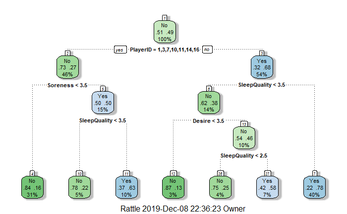

```r
wellness5 = wellness2
wellness5=wellness5[-c(11,18,19)]

wellness5 = wellness5[-c(3)]
well5.rpart1 = rpart(notFatigued~.,data=wellness5)
fancyRpartPlot(well5.rpart1)
```

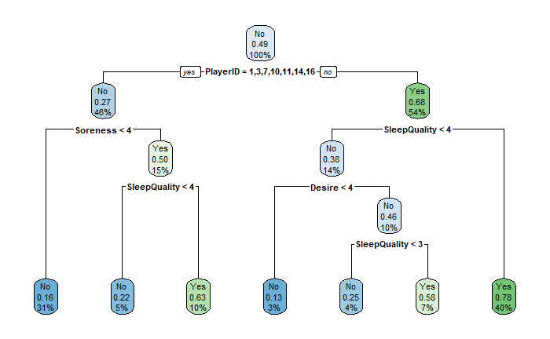

```r
rpart.plot(well5.rpart1)
```

```r
summary(well5.rpart1)
```

```
Call:
rpart(formula = notFatigued ~ ., data = wellness5)
  n= 5011

          CP nsplit rel error    xerror       xstd
1 0.39861845      0 1.0000000 1.0000000 0.01437977
2 0.06501422      1 0.6013816 0.6265746 0.01327610
3 0.02702154      2 0.5363673 0.5542462 0.01280269
4 0.01076798      4 0.4823243 0.4843560 0.01224727
5 0.01000000      6 0.4607883 0.4815116 0.01222244

Variable importance
         PlayerID      SleepQuality          Soreness            Desire      Irritability TrainingReadiness        SleepHours
               37                23                16                12                 5                 5                 1
         WakeTime
                1

Node number 1: 5011 observations,    complexity param=0.3986184
  predicted class=No   expected loss=0.4911195  P(node) =1
    class counts:  2550  2461
   probabilities: 0.509 0.491
  left son=2 (2298 obs) right son=3 (2713 obs)
  Primary splits:
      PlayerID     splits as  LRLRRRLRRLLRRLRLR, improve=425.6786, (0 missing)
      Desire       < 3.5     to the left,  improve=410.4550, (0 missing)
      Soreness     < 3.5     to the left,  improve=370.6253, (0 missing)
      SleepQuality < 3.5     to the left,  improve=330.9610, (0 missing)
      Irritability < 3.5     to the left,  improve=196.9897, (0 missing)
  Surrogate splits:
      Desire            < 3.5     to the left,  agree=0.660, adj=0.258, (0 split)
      Soreness          < 3.5     to the left,  agree=0.618, adj=0.167, (0 split)
      TrainingReadiness < 92.5    to the right, agree=0.602, adj=0.132, (0 split)
      Irritability      < 3.5     to the left,  agree=0.591, adj=0.107, (0 split)
      SleepQuality      < 3.5     to the left,  agree=0.589, adj=0.103, (0 split)

Node number 2: 2298 observations,    complexity param=0.02702154
  predicted class=No   expected loss=0.2671889  P(node) =0.4585911
    class counts:  1684   614
   probabilities: 0.733 0.267
  left son=4 (1564 obs) right son=5 (734 obs)
```

[output cut: 104 more lines]

```
      SleepHours   < 7.375   to the left,  agree=0.710, adj=0.165, (0 split)
      BedTime      < 71100   to the left,  agree=0.691, adj=0.110, (0 split)
      PlayerID     splits as  -R-LRR-RL--RR-R-R, agree=0.665, adj=0.033, (0 split)
      Irritability < 2.5     to the left,  agree=0.665, adj=0.033, (0 split)
      Illness      splits as  RRL, agree=0.663, adj=0.027, (0 split)

Node number 26: 182 observations
  predicted class=No   expected loss=0.2527473  P(node) =0.0363201
    class counts:   136    46
   probabilities: 0.747 0.253

Node number 27: 343 observations
  predicted class=Yes  expected loss=0.4227405  P(node) =0.06844941
    class counts:   145   198
   probabilities: 0.423 0.577
```

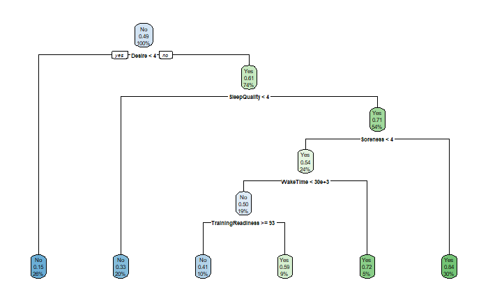

```r
wellness6=wellness5[-c(2)]
well6.rpart1 = rpart(notFatigued~., data=wellness6)
rpart.plot(well6.rpart1)
```

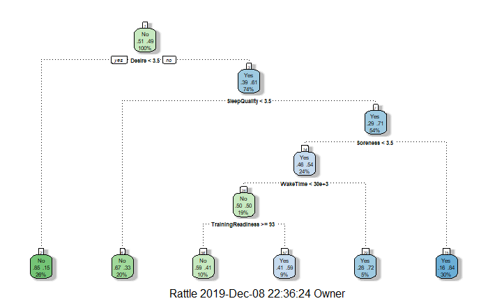

```r
fancyRpartPlot(well6.rpart1)
```

```r
summary(well6.rpart1)
```

```
Call:
rpart(formula = notFatigued ~ ., data = wellness6)
  n= 5011

          CP nsplit rel error    xerror       xstd
1 0.33238521      0 1.0000000 1.0000000 0.01437977
2 0.13734254      1 0.6676148 0.6676148 0.01350302
3 0.01191927      2 0.5302722 0.5302722 0.01262363
4 0.01000000      5 0.4945144 0.5209265 0.01255065

Variable importance
           Desire      SleepQuality          Soreness      Irritability          WakeTime TrainingReadiness        SleepHours
               45                24                14                 6                 3                 3                 2
          Illness           BedTime
                1                 1

Node number 1: 5011 observations,    complexity param=0.3323852
  predicted class=No   expected loss=0.4911195  P(node) =1
    class counts:  2550  2461
   probabilities: 0.509 0.491
  left son=2 (1279 obs) right son=3 (3732 obs)
  Primary splits:
      Desire       < 3.5     to the left,  improve=410.45500, (0 missing)
      Soreness     < 3.5     to the left,  improve=370.62530, (0 missing)
      SleepQuality < 3.5     to the left,  improve=330.96100, (0 missing)
      Irritability < 3.5     to the left,  improve=196.98970, (0 missing)
      Date         < 17493.5 to the right, improve= 68.77561, (0 missing)
  Surrogate splits:
      Irritability < 3.5     to the left,  agree=0.777, adj=0.125, (0 split)
      Soreness     < 1.5     to the left,  agree=0.750, adj=0.022, (0 split)
      Illness      splits as  RRL,         agree=0.750, adj=0.022, (0 split)
      SleepHours   < 4.625   to the left,  agree=0.748, adj=0.013, (0 split)
      WakeTime     < 13050   to the left,  agree=0.746, adj=0.005, (0 split)

Node number 2: 1279 observations
  predicted class=No   expected loss=0.1454261  P(node) =0.2552385
    class counts:  1093   186
   probabilities: 0.855 0.145

Node number 3: 3732 observations,    complexity param=0.1373425
```

[output cut: 77 more lines]

```

Node number 29: 258 observations
  predicted class=Yes  expected loss=0.2829457  P(node) =0.05148673
    class counts:    73   185
   probabilities: 0.283 0.717

Node number 56: 484 observations
  predicted class=No   expected loss=0.4090909  P(node) =0.09658751
    class counts:   286   198
   probabilities: 0.591 0.409

Node number 57: 463 observations
  predicted class=Yes  expected loss=0.4103672  P(node) =0.09239673
    class counts:   190   273
   probabilities: 0.410 0.590
```

With the RPart tree model, I’m able to identify individual variables’ influence over the model. With the inclusion of Player IDs, the highest contributing factors seem to be soreness and sleep quality, logically suggesting that players who are less sore/have better sleep report lower levels of fatigue. However, when PlayerIDs are removed from the equation, desire becomes more influential, with sleep quality and soreness falling behind, suggesting that desire is definitely linked to each individual player and their personal attitudes towards their performance in the game. All in all, my suggestion to the Canadian Women’s Rugby Sevens team would be to make concentrated efforts to alliviate any physical fatigue/sleep issues in conjunction with their training, and to look into programs that may increase morale among players.